# My Simple Logistic Regression

## Background

In the university Math Study center around 130 students are seen per day, These students come in to the study center for various reasons but they are all related in some way to math. I obtained data from the faculty supervisors on student attendance of the lab as well as 1-on-1 tutoring appointments. I wanted to determine if using time spent in the Math lab (Study center) is a valid way to predict what type of math a student was working on in the lab. I will attempt to do this by using the time spent in in the lab (minutes), and the course a student attended the lab for. I work in the lab as a statistics tutor and I’ve always felt like students who come in for a stats based course spend a bit more time in the lab than those who come in to study algebra or calculus.

*Note:* Students who forget to sign out of the lab have their time set to equal 60 minutes. I will use this when I split the data into stats vs non stats groups the conditionally change the time spend value for students with a time equal to 60 minutes to the average time spent by students in that group who did remember to sign out. This is the reason that a significant count of obvservations show as either 57 or 59 minutes in the final dataframe.

## Hypothese and Logistic Regression Model

The following logistic regression model will be used:

$$P(Y_i = 1|\, x_i) = \frac{e^{\beta_0 + \beta_1 x_i}}{1+e^{\beta_0 + \beta_1 x_i}} = \pi_i$$

If B1 in our model is equal to zero this would indicate that xi (time spent in the lab) gives us no information on what type of math class a student is more likely attending for. Thus my hypotheses are as follows:
$$\begin{array}{ll}
H_0: \beta_1 = 0\\
H_a: \beta_1 \neq 0\
\end{array}$$

$$\alpha = 0.05$$

```r
lab <- read_csv("C:/Users/user/OneDrive/Desktop/Stats stuff/325 book/Statistics-Notebook-master/CenterVisitReportSPLIT.csv")

labmin <- filter(lab, `Visit_duration` >= 1)
labmin <- labmin[ -c(9) ]

Slist <- c("MATH 221A", "MATH 221B", "MATH 221C", "MATH 325", "MATH 425", "MATH 326")
Mlist <- c("MATH 100A", "MATH 100B", "MATH 101", "MATH 108X", "MATH 109", "MATH 110X", "MATH 111", "MATH 112X", "MATH 113", "MATH 119", "MATH 191", "MATH 205", "MATH 214","MATH 215", "MATH 275", "MATH 280", "MATH 316", "MATH 330", "MATH 340", "MATH 341", "MATH 350")
```

```r
library(tidyr)
library(dplyr)
labmindi <- filter(labmin, labmin$`Slot _Type` == "DropIn")
labmindp <-labmindi
labmindp$nonmath <- case_when(labmindp$`Course` %in% Slist == FALSE & labmindp$`Course` %in% Mlist == FALSE ~ 1, labmindp$`Course` %in% Slist == TRUE | labmindp$`Course` %in% Mlist == TRUE ~ 0)

labmindp <-labmindp[!(labmindp$nonmath == 1),]
#find Q1, Q3, and interquartile range for values in column family
Q1 <- quantile(labmindp$`Visit_duration`, .25, na.rm = TRUE)
Q3 <- quantile(labmindp$`Visit_duration`, .75, na.rm = TRUE)
IQR <- IQR(labmindp$`Visit_duration`, na.rm = TRUE)


#only keep rows in dataframe that have values within 1.5*IQR of Q1 and Q3
LCD <- subset(labmindp, labmindp$`Visit_duration`> (Q1 - 1.5*IQR) & labmindp$`Visit_duration`< (Q3 + 1.5*IQR))



LCD$stats <- case_when(LCD$`Course` %in% Slist == TRUE ~ 1, LCD$`Course` %in% Mlist == TRUE  ~ 0 )
```

```r
LCDIS <- filter(LCD, LCD$`Course` %in% Slist == TRUE & LCD$`Visit_duration` !=60)
LCDNS <- filter(LCD, LCD$`Course` %in% Mlist == TRUE & LCD$`Visit_duration` !=60)
LCDISD <- filter(LCD, LCD$`Course` %in% Slist == TRUE)
LCDNSD <- filter(LCD, LCD$`Course` %in% Mlist == TRUE)
```

```r
#favstats(LCDIS$`Visit_duration`)
#mean in stats 59.23
#favstats(LCDNS$`Visit_duration`)
#mean not in stats 57.89

#hist(LCDNSD$`Visit_duration`)
#hist(LCDISD$`Visit_duration`)


LCDAVG <- LCD
LCDAVG$`Visit_duration` <- case_when(LCD$`Course` %in% Slist == TRUE & LCD$`Visit_duration` ==60 ~ 59.23,
                                                  LCD$`Course` %in% Mlist == TRUE & LCD$`Visit_duration` ==60 ~ 57.89,
                                                  LCD$`Course` %in% Mlist == FALSE & LCD$`Course` %in% Slist == FALSE ~ LCD$`Visit_duration`,
                                                  LCD$`Visit_duration` !=60 ~ LCD$`Visit_duration` )

#labmindiAVG$`Visit_duration` <- case_when(labmindi$`Course` %in% clist == TRUE & labmindi$`Visit_duration` ==60 ~ 65.27,labmindi$`Course` %in% clist == FALSE & labmindi$`Visit_duration` ==60 ~ 64.27, labmindi$`Visit_duration` !=60 ~ labmindi$`Visit_duration`)
```

### Data

```r
datatable(LCDAVG)
```

|  | Course | Professor | Slot _Type | S_Class | S_Type | Visit_duration | Date_Time | Status | Day_of_week | Date | nonmath | stats |
| --- | --- | --- | --- | --- | --- | --- | --- | --- | --- | --- | --- | --- |
| 1 | MATH 100B | Alisha Oldroyd | DropIn | Freshman | OnCampus | 57.89 | 11/9/2021 15:41 | Check In | 2 | 11/9/2021 | 0 | 0 |
| 2 | MATH 108X | Kent Bessey | DropIn | Sophomore | OnCampus | 57.89 | 11/9/2021 15:38 | Check In | 2 | 11/9/2021 | 0 | 0 |
| 3 | MATH 100B | Rachel Hurst | DropIn | Freshman | OnCampus | 57.89 | 11/9/2021 15:35 | Check In | 2 | 11/9/2021 | 0 | 0 |
| 4 | MATH 221A | Emily Walsh | DropIn | Sophomore | OnCampus | 59.23 | 11/9/2021 15:29 | Check In | 2 | 11/9/2021 | 0 | 1 |
| 5 | MATH 215 | Troy Goodsell | DropIn | Junior | OnCampus | 57.89 | 11/9/2021 15:24 | Check In | 2 | 11/9/2021 | 0 | 0 |
| 6 | MATH 108X | Matt Webb | DropIn | Freshman | OnCampus | 57.89 | 11/9/2021 15:13 | Check In | 2 | 11/9/2021 | 0 | 0 |
| 7 | MATH 215 | Troy Goodsell | DropIn | Senior | OnCampus | 57.89 | 11/9/2021 15:12 | Check In | 2 | 11/9/2021 | 0 | 0 |
| 8 | MATH 221C | Melanie Kennelly | DropIn | Sophomore | OnCampus | 59.23 | 11/9/2021 15:11 | Check In | 2 | 11/9/2021 | 0 | 1 |
| 9 | MATH 112X | Matthew Lewis | DropIn | Sophomore | OnCampus | 57.89 | 11/9/2021 15:02 | Check In | 2 | 11/9/2021 | 0 | 0 |
| 10 | MATH 108X | Curtis Nelson | DropIn | Freshman | OnCampus | 57.89 | 11/9/2021 15:02 | Check In | 2 | 11/9/2021 | 0 | 0 |

[output cut: 3823 more lines]

### Data Summary

```r
favstats(`Visit_duration` ~ `stats`, data = LCDAVG)%>%
pander(caption="Time spent in lab for students working ona stats related course or not.")
```

Time spent in lab for students working ona stats related course or not.

| stats | min | Q1 | median | Q3 | max | mean | sd | n | missing |
| --- | --- | --- | --- | --- | --- | --- | --- | --- | --- |
| 0 | 1.18 | 38.67 | 57.89 | 70.95 | 151.4 | 59.54 | 32.94 | 3225 | 0 |
| 1 | 3.76 | 49.23 | 59.23 | 70.26 | 148.7 | 62.66 | 27.14 | 608 | 0 |

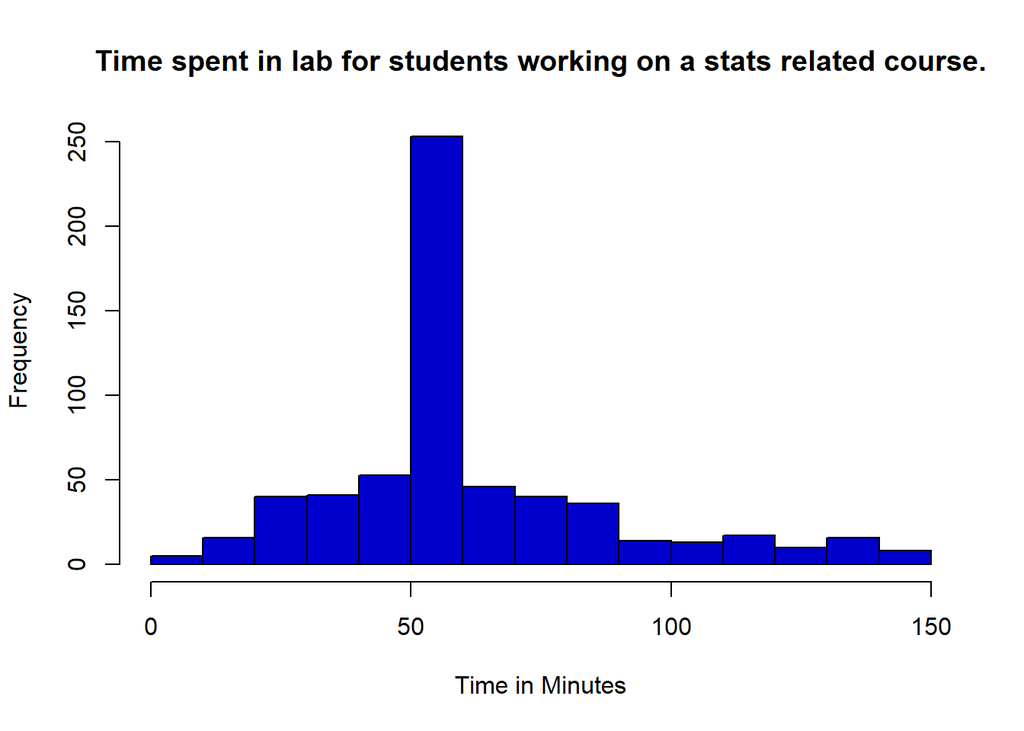

```r
hist(LCDISD$`Visit_duration`, main= "Time spent in lab for students working on a stats related course.", col="blue3", xlab="Time in Minutes",)
```

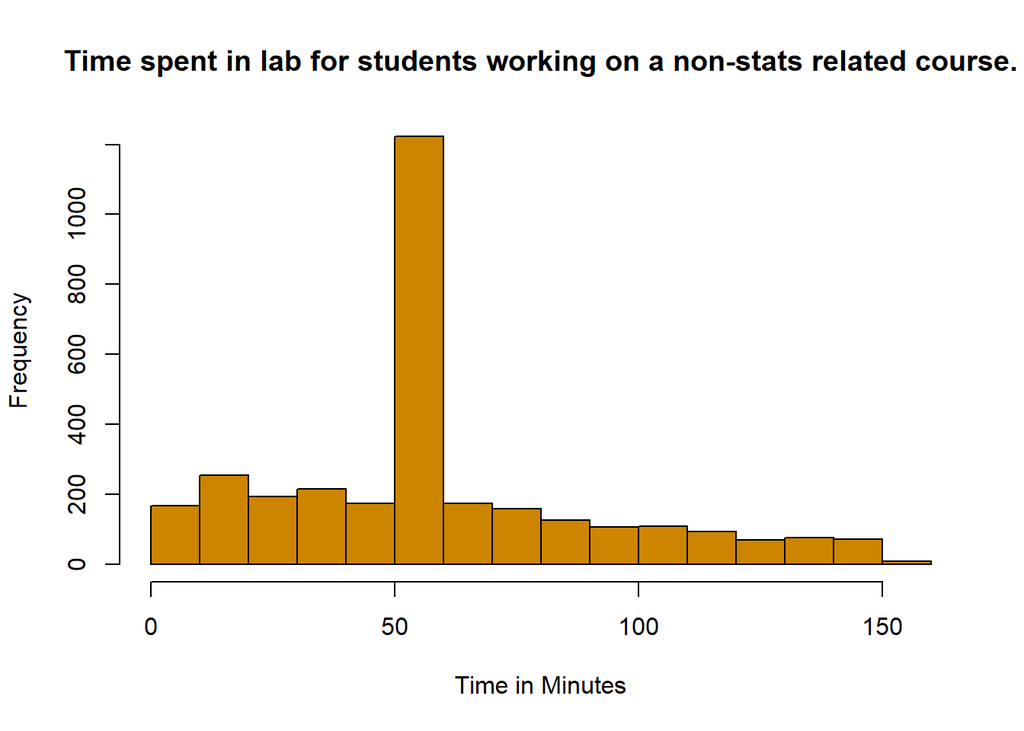

```r
hist(LCDNSD$`Visit_duration`, main= "Time spent in lab for students working on a non-stats related course.", col="orange3", xlab="Time in Minutes",)
```